# 4. 过拟合

Deep Learning I

4. 过拟合

WU Xiaokun 吴晓堃

xkun.wu [at] gmail

2021/03/14

# 模型选择

## 一致逼近原理

### Universal approximation theorem（非常有用的废话）

In approximation theory, both *shallow* and *deep* networks are known to **approximate any continuous functions** at an **exponential cost**.

就像C语言：能够表达**任何可计算的程序**

- 问题是：如何把这个程序符合规范地写出来？
- 指数级复杂度：NP问题

## 回顾：模型参数

**测试集**：实际应用时才能拿到的数据

- 对于训练过程来说是**未知**的
- 测试集划分：二八原则

类比：训练集=日常习题；测试集=考试题

- 训练参数的过程：通过习题掌握解题思路

## 超参数

超参数：“参数的参数”；模型的**种类**

- 模型、黑盒函数、超参数：三者等价

$$\begin{aligned}
\textbf{h}_1 &= \sigma(\textbf{W}_1 \textbf{x} + \textbf{b}_1)\\
\textbf{h}_2 &= \sigma(\textbf{W}_2 \textbf{h}_1 + \textbf{b}_2)\\
\textbf{h}_3 &= \sigma(\textbf{W}_3 \textbf{h}_2 + \textbf{b}_3)\\
\textbf{o} &= \textbf{W}_o \textbf{h}_3 + \textbf{b}_o\\
\end{aligned}$$

超参数：取决于模型的**设计**

- 隐藏层数
- 每个隐藏层的大小

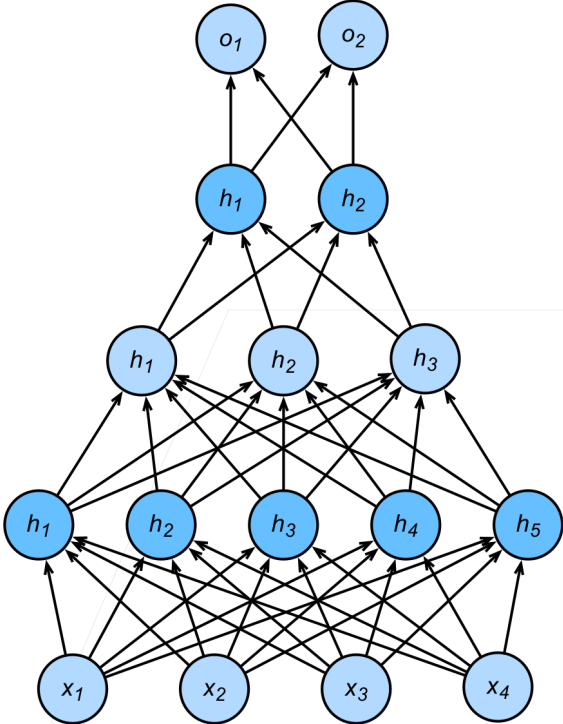

- 注意：模型本身的参数是**学习**得到的

## 模型选择、参数估计

超参数一旦确定，模型也就确定

- 确定超参数的过程称为**模型选择**
- 确定超参数的方法称为**参数估计**

参数估计的方法

- 统计学习：最小二乘、最大似然、最大后验
- 手工方法：凭**经验**选择与试错
  - 所以也称“手气法”、“炼丹”
  - 目前深度学习最常用的方法

## 计算与应用

机器学习计算与应用的**矛盾**

- 计算过程：已知数据，即训练集
- 应用场景：未知数据，即测试集

例如：训练集中只有动物的图片，应用却是人脸识别

- 《戴珍珠耳环的少女》：什么叫做惊喜？长得像
- 案例：种族歧视

[figure not shown]

## 独立同分布假设

理论上：训练集和测试集的数据分布必须一致

- **独立同分布假设 i.i.d.**
- 对数据进行采样的过程没有进行“操控”
  - 无论如何采样，数据分布都是一样的

实际应用：不可能

- 尽可能地收集与测试相近的数据
  - 习题要尽量像考试题
- 机器学习的**bug之一**
  - 早期机器学习实践：基本等于数据工程
  - 万万没想到：深度学习横空出世

## 训练误差、泛化误差

评测机器学习算法有两个维度

- **训练误差**：训练阶段，已知数据上的优化误差
- **泛化误差**：测试阶段，未知数据上的泛化误差

例如：

- 日常习题成绩：训练误差
- 真实考试成绩：泛化误差

## 训练误差越低越好？

考虑预测抛硬币的结果，假设硬币是公平的

- 无论采用什么算法，泛化误差一定是$0.5$

假设训练集是$\{1，1，1，0，1\}$

- 预测器：始终输出固定值$1$，训练误差只有$0.2$

## 泛化与逻辑

机器学习的**根本问题**：从数据中发现可以泛化的模式

- 从而减小泛化误差
- 学习必须能够迫使机器**理解完成任务的逻辑**

例如：$28×28$的$8$位单通道灰度图片

- $2^{8}=256$个灰度值；$28 \times 28 = 784$个像素
  - 总共$256^{784}$种可能性，不可能被完全记住

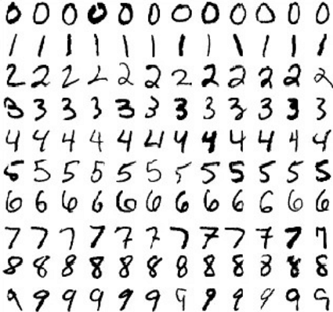

例如：$19×19$的围棋棋盘

## 验证集、测试集

**验证集**：调超参数时用的数据集

- 对于训练过程来说是**已知**的

类比考试：

- 训练集=日常习题；测试集=考试题
- 验证集=模拟考试题

## 为什么模拟考试题不能重复？

模拟考试的目的：**预测未来**真实考试的分数

- 注意讨论的问题：**考试、学习的有效性**

模拟考试分数高，真实考试分数不一定高

- 模拟试题与真实试题差异巨大
- 某次模拟考试发挥超常

模拟考试需要进行多次；每次的试题不能一样

- 减小与真实试题之间的差距
- 减小猜题、背题等运气成分
  - 必须**理解解答问题的逻辑**

## 验证集划分

最简单的方法：固定比例

- 例如：“二八原则”
- 相当于**模拟考试题雷同**

问题：模型**间接推测**出数据分布怎么办？

- 多次重复提交评测：根据评测结果修改模型
- 考试能多次提交吗？根据打分修改解题方法

## 信息泄露

多次重复验证：**间接推测**出验证集分布

- “卷竞赛”：暴力刷分=作弊
  - （负面）案例：禁赛事件
  - 道德、法律风险

## K 折交叉验证

重复使用训练数据，但模拟出每次都不一样的效果

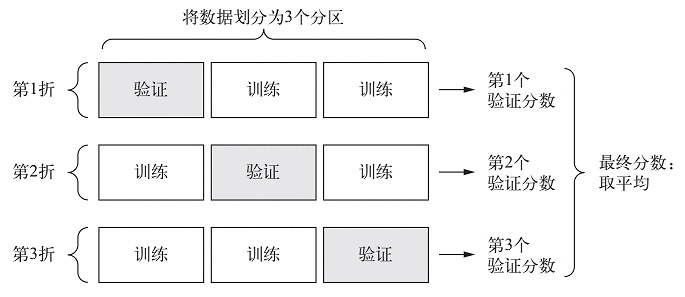

也在**数据量比较少**的时候应用

# 欠拟合和过拟合

## 创意？

就像观星一样**过度解读**数据

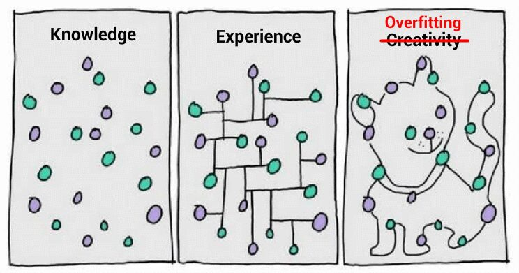

是创意吗？不，只是过拟合

## 欠拟合、过拟合

- **欠拟合**：训练误差不下降；两种误差接近平行
  - 习题没做够，没有掌握规律
- **过拟合**：训练误差很小，泛化误差达到低点后开始增大
  - 开始死记硬背，但模拟题与考试题不一样

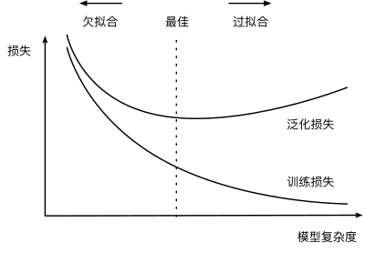

## 多项式拟合

$$y = a_0 + a_1 x + a_2 x^2 + a_3 x^3 + ...$$

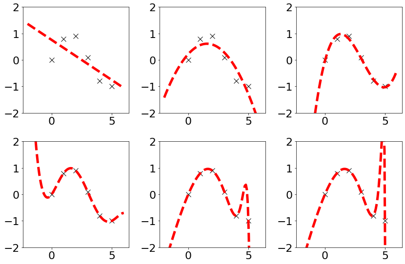

多项式次数：$1, 2, 3, 5, 30, 100$，代表模型、计算复杂度

- 剧烈波动：异常规律；如果数据没错，模型必定出错

## 模型容量

拟合函数的能力：可以简单认为是模型**参数的数量**

- 低容量：欠拟合，不足以发现复杂规律
- 高容量：过拟合，记住所有训练数据

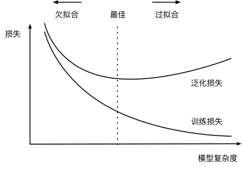

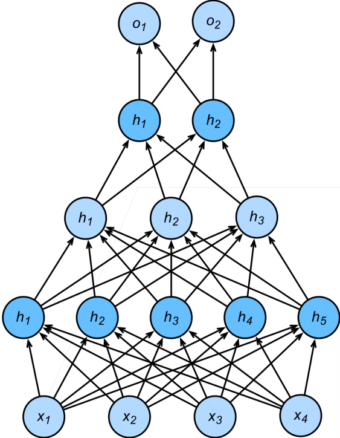

## 财富和幸福

幸福指数对财富增长不是固定比率关系

- 更真实的情况应该是财富按比例增长
  - 例如1000块工资涨幅对于1亿财富
  - 在**对数空间**应该是线性关系
    - 无法直接观测的
- 第二个数据点应该是其他方面的问题

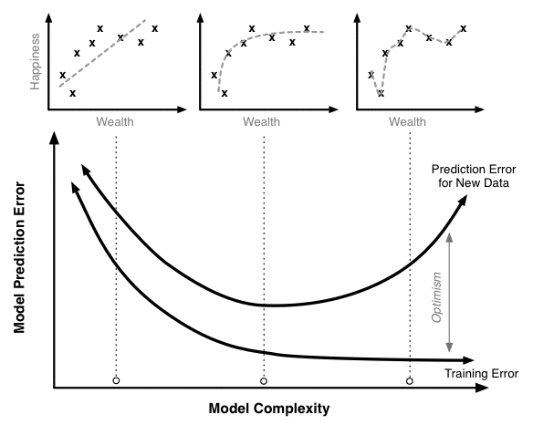

## 数据复杂度

模型容量需要匹配数据复杂度

- 实际应用主要是**（钱）数据量不足**的问题
  - 数据量太少导致模型相对复杂：容易过拟合

几个重要因素

- 样本个数
- 每个样本的元素数量：通道、像素数
- 时间、空间结构：天在上、海在下
- 多样性：不同姿态，类别平衡

## 估计模型容量

一般难以在不同种类的算法之间比较

- 例如：树模型、感知机之间没有可比性

给定模型种类，可以简单判断区别

- 参数个数
- 参数值的取值范围

## VC维

统计学习理论，人名缩写，不是“维C”

> 给定分类模型，确定一个最大的数据量：可以被完美分类。

例如二维输入的感知机，不能解决“XOR问题”，VC维=3

## VC维的作用

从数学上提供模型好坏的理论依据

- 确定数据量大小，估计模型容量

深度学习中很少使用

- 度量不太准确
- 计算非常困难

数学理论的特点：一般无法在工程实践上应用

## 实验：多项式拟合

# 权重衰减

## 减轻过拟合

无限（钱）数据量的情况

- 无论模型多复杂，都不会出现过拟合

限制参数：技巧往往是**无奈之选**

- 参数个数：降低模型复杂度
- 参数值大小

## 减轻过拟合：Occam剃刀原则

无限（钱）数据量的情况

- 无论模型多复杂，都不会出现过拟合

限制参数：技巧往往是**无奈之选**

- 参数个数：降低模型复杂度
- 参数值大小

**Occam剃刀原则**：更简单的往往也是更好的

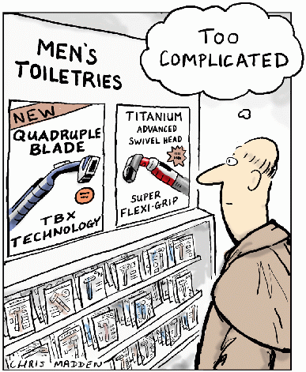

## 为什么要限制参数值大小？

参数值大小代表自变量的“**影响力**”

$$y = w_1x_1 + w_2x_2 + .. + w_dx_d + b$$

- 参数值过大：输入微小变动，输出巨幅变化
  - 例如分类：导致类别发生变化
- 等价于过拟合：模型**“适应”了（异常）训练数据**
  - 数据拟合理论：异常值的重要性更高，进而拉升对应参数数值

但测试数据中，输入的取值范围可能不一样

- 模型**无法适应测试数据**：导致分类错误

## 硬性约束

优化问题：添加**约束条件**

$$\argmin \mathcal{L}(\mathbf{w},b), \text{s.t.} \lVert \textbf{w} \rVert^2 \le \theta$$

- 通常不限制偏移量$b$
  - 常数项的影响力不大；加法运算数值上比较稳定
- $\theta$越小：过拟合控制得越好

## 柔性约束

优化问题的求解：**Language乘数法**

$$\begin{aligned}
&~ \argmin \mathcal{L}(\mathbf{w},b), \text{s.t.} \lVert \textbf{w} \rVert^2 \le \theta\\
&~ \argmin \mathcal{L}(\mathbf{w},b) + \frac{\lambda}{2} \lVert \textbf{w} \rVert^2
\end{aligned}$$

- 也称**正则化方法 regularization**
- 超参数$\lambda$控制正则项（即约束条件）的强度
  - $\lambda \rightarrow \infty$时：$\textbf{w} \rightarrow 0$

## 正则化对最优解的影响

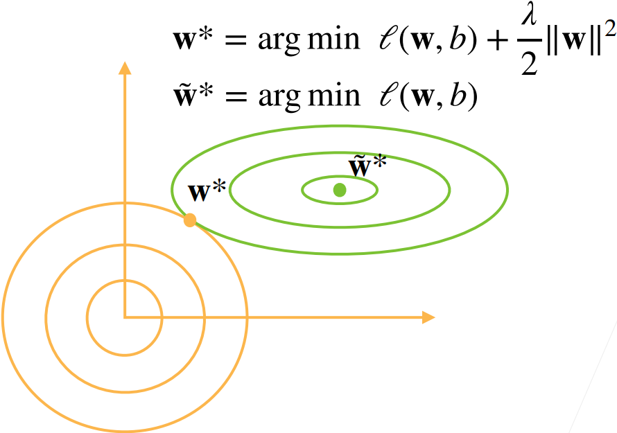

- 把参数值**“拉向”原点**：原点附近数值更小

## 更新法则

梯度

$$\frac{\partial}{\partial \mathbf{w}} \left( \mathcal{L}(\mathbf{w},b) + \frac{\lambda}{2} \lVert \textbf{w} \rVert^2 \right)
= \frac{\partial}{\partial \mathbf{w}} \mathcal{L}(\mathbf{w},b) + \lambda \textbf{w}$$

更新参数

$$\mathbf{w}_{t+1} = (1-\eta \lambda) \mathbf{w}_{t} - \eta \frac{\partial}{\partial \mathbf{w}_{t}} \mathcal{L}(\mathbf{w}_{t},b_t)$$

- 通常$\eta \lambda < 1$，因此通常称为**权重衰退 weight decay**

## 其他正则化

$L_2$正则化，也称**脊回归 ridge regression**

$$\argmin \mathcal{L}(\mathbf{w},b) + \frac{\lambda}{2} \lVert \textbf{w} \rVert^2$$

$L_1$正则化，也称**套索回归 lasso regression**

$$\argmin \mathcal{L}(\mathbf{w},b) + \lambda \lvert \textbf{w} \rvert$$

一般情况：$L_n$正则化

$$\argmin \mathcal{L}(\mathbf{w},b) + \lambda \lVert \textbf{w} \rVert_n$$

## 自动微分计算图

$$\begin{aligned}
\textbf{h} &= \sigma(\textbf{W}_h \textbf{x} + \textbf{b}_h)\\
\textbf{o} &= \textbf{W}_o \textbf{h} + \textbf{b}_o\\
s &= \frac{\lambda}{2} \left( \lVert \textbf{W}_h \rVert_F^2 + \lVert \textbf{W}_o \rVert_F^2 \right)\\
\end{aligned}$$

$$\begin{aligned}
\textbf{z} &= \textbf{W}_h \textbf{x}\\
\textbf{h} &= \phi(\textbf{z})\\
\textbf{o} &= \textbf{W}_o \textbf{h}\\
\mathcal{L} &= l(O,y)\\
\end{aligned}$$

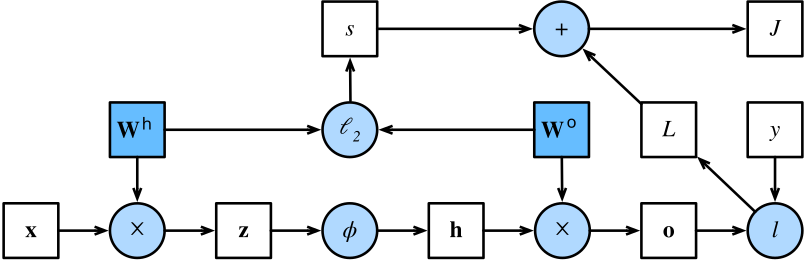

## 实验：权重衰退

# 丢弃法

## Dropout

Dropout：劝退

[figure not shown]

注意：标准高不等于内卷！

> 普通人有上上智。– 李克强

## 什么是好模型？

**Occam剃刀原则**：更简单的往往也是更好的

- 限制参数的个数、取值

**鲁棒性原则**：对输入数据的噪音不敏感

- [Bishop 1995] 具有输入噪声的训练等价于Tikhonov正则化
- 训练时**给模型加入噪音**
  - 相当于模拟有噪音的输入：“制造困难也要上”

## 无偏噪音

假设对$\mathbf{x}$加入噪音得到$\mathbf{x}'$：相当于**直接修改数据**

- 因此应该保证**数据分布不发生偏移**：$\mathbb{E}[\mathbf{x}'] = \mathbf{x}$

**丢弃法 Dropout**：对每个元素做无偏随机扰动

- 按照概率缩小（清0）一部分数据：剩下的部分必须要**放大相应的量**

$$x_i' = \left\{ \begin{array}{ll}
0 & \text{概率}\ p \\
\frac{x_i}{1-p} & \text{otherwise} \\
\end{array}\right.$$

- **丢弃率$p$**是超参数
- 验证**无偏**：计算期望，$p * 0 + (1-p) * \frac{x_i}{1-p}$

## 使用丢弃法

丢弃法通常作用在**隐藏层的输出**上

$$\begin{aligned}
\textbf{h} &= \sigma(\textbf{W}_1 \textbf{x} + \textbf{b}_1)\\
\textbf{h}' &= \text{dropout}(\textbf{h})\\
\textbf{o} &= \textbf{W}_o \textbf{h}' + \textbf{b}_o\\
\end{aligned}$$

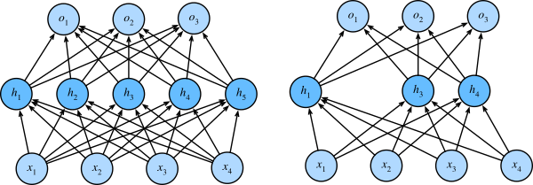

## 评测过程

正则化方法都**只在训练中使用**

- 训练更新部分参数；其余参数不参与优化，保持随机化状态

评测过程中，丢弃法直接返回原输入

$$\begin{aligned}
\textbf{h} &= \text{dropout}(\textbf{h})\\
\end{aligned}$$

- 保证**输出的确定性**：架构、参数保持不变

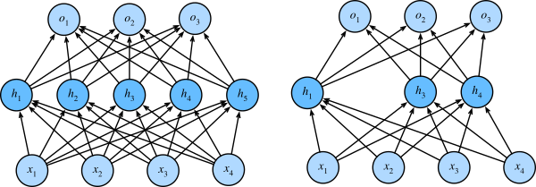

## 实验：丢弃法

# 实战Kaggle比赛：预测房价